# Анализ рынка компьютерных игр

**Описание проекта**

Для интернет-магазина «Стримчик» компьютерных игр необходимо провести анализ рынка, выявить определяющие успешность игры закономерности, определить портрет пользователя для каждого из регионов, проверить рабочие гипотезы. Это позволит сделать ставку на потенциально популярный продукт и спланировать рекламные кампании, помочь развитию бизнеса магазина.

Из открытых источников собраны исторические данные о продажах игр, оценки пользователей и экспертов, жанры и платформы за 1980 -2016 года, записаны в файле games.csv.

**Описание данных games.csv:**

- Name — название игры
- Platform — платформа
- Year_of_Release — год выпуска
- Genre — жанр игры
- NA_sales — продажи в Северной Америке (миллионы проданных копий)
- EU_sales — продажи в Европе (миллионы проданных копий)
- JP_sales — продажи в Японии (миллионы проданных копий)
- Other_sales — продажи в других странах (миллионы проданных копий)
- Critic_Score — оценка критиков (максимум 100)
- User_Score — оценка пользователей (максимум 10)
- Rating — рейтинг от организации ESRB (англ. Entertainment Software Rating Board). Эта ассоциация определяет рейтинг компьютерных игр и присваивает им подходящую возрастную категорию.

## Загрузим файл с данными и изучим общую информацию

```python
# импорт библиотек
import pandas as pd
import numpy as np
from scipy import stats as st
import seaborn as sns
import matplotlib.pyplot as plt
%matplotlib inline

pd.set_option('display.max_rows', 500)
pd.set_option('display.max_columns', 500)
pd.set_option('display.width', 1000)
```

```python
# чтение файла с данными с сохранением в data
try:
    data = pd.read_csv(r"B:\Downloads\games.csv", sep = ',')
except:
    data = pd.read_csv("https://code.s3.yandex.net/datasets/games.csv", sep = ',')
```

```python
# создаем функцию для изучения общей информации о полученном датафрейме
def datainfo(dataframe):
    display(dataframe.head(10))
    display(dataframe.shape)
    display(dataframe.describe())
    display(dataframe.info())
    display(dataframe.duplicated())
datainfo(data)
```

|  | Name | Platform | Year_of_Release | Genre | NA_sales | EU_sales | JP_sales | Other_sales | Critic_Score | User_Score | Rating |
| --- | --- | --- | --- | --- | --- | --- | --- | --- | --- | --- | --- |
| 0 | Wii Sports | Wii | 2006.0 | Sports | 41.36 | 28.96 | 3.77 | 8.45 | 76.0 | 8 | E |
| 1 | Super Mario Bros. | NES | 1985.0 | Platform | 29.08 | 3.58 | 6.81 | 0.77 | NaN | NaN | NaN |
| 2 | Mario Kart Wii | Wii | 2008.0 | Racing | 15.68 | 12.76 | 3.79 | 3.29 | 82.0 | 8.3 | E |
| 3 | Wii Sports Resort | Wii | 2009.0 | Sports | 15.61 | 10.93 | 3.28 | 2.95 | 80.0 | 8 | E |
| 4 | Pokemon Red/Pokemon Blue | GB | 1996.0 | Role-Playing | 11.27 | 8.89 | 10.22 | 1.00 | NaN | NaN | NaN |
| 5 | Tetris | GB | 1989.0 | Puzzle | 23.20 | 2.26 | 4.22 | 0.58 | NaN | NaN | NaN |
| 6 | New Super Mario Bros. | DS | 2006.0 | Platform | 11.28 | 9.14 | 6.50 | 2.88 | 89.0 | 8.5 | E |
| 7 | Wii Play | Wii | 2006.0 | Misc | 13.96 | 9.18 | 2.93 | 2.84 | 58.0 | 6.6 | E |
| 8 | New Super Mario Bros. Wii | Wii | 2009.0 | Platform | 14.44 | 6.94 | 4.70 | 2.24 | 87.0 | 8.4 | E |
| 9 | Duck Hunt | NES | 1984.0 | Shooter | 26.93 | 0.63 | 0.28 | 0.47 | NaN | NaN | NaN |

```
(16715, 11)
```

|  | Year_of_Release | NA_sales | EU_sales | JP_sales | Other_sales | Critic_Score |
| --- | --- | --- | --- | --- | --- | --- |
| count | 16446.000000 | 16715.000000 | 16715.000000 | 16715.000000 | 16715.000000 | 8137.000000 |
| mean | 2006.484616 | 0.263377 | 0.145060 | 0.077617 | 0.047342 | 68.967679 |
| std | 5.877050 | 0.813604 | 0.503339 | 0.308853 | 0.186731 | 13.938165 |
| min | 1980.000000 | 0.000000 | 0.000000 | 0.000000 | 0.000000 | 13.000000 |
| 25% | 2003.000000 | 0.000000 | 0.000000 | 0.000000 | 0.000000 | 60.000000 |
| 50% | 2007.000000 | 0.080000 | 0.020000 | 0.000000 | 0.010000 | 71.000000 |
| 75% | 2010.000000 | 0.240000 | 0.110000 | 0.040000 | 0.030000 | 79.000000 |
| max | 2016.000000 | 41.360000 | 28.960000 | 10.220000 | 10.570000 | 98.000000 |

```
<class 'pandas.core.frame.DataFrame'>
RangeIndex: 16715 entries, 0 to 16714
Data columns (total 11 columns):
 #   Column           Non-Null Count  Dtype
---  ------           --------------  -----
 0   Name             16713 non-null  object
 1   Platform         16715 non-null  object
 2   Year_of_Release  16446 non-null  float64
 3   Genre            16713 non-null  object
 4   NA_sales         16715 non-null  float64
 5   EU_sales         16715 non-null  float64
 6   JP_sales         16715 non-null  float64
 7   Other_sales      16715 non-null  float64
 8   Critic_Score     8137 non-null   float64
 9   User_Score       10014 non-null  object
 10  Rating           9949 non-null   object
dtypes: float64(6), object(5)
memory usage: 1.4+ MB
```

```
None
```

```
0        False
1        False
2        False
3        False
4        False
         ...
16710    False
16711    False
16712    False
16713    False
16714    False
Length: 16715, dtype: bool
```

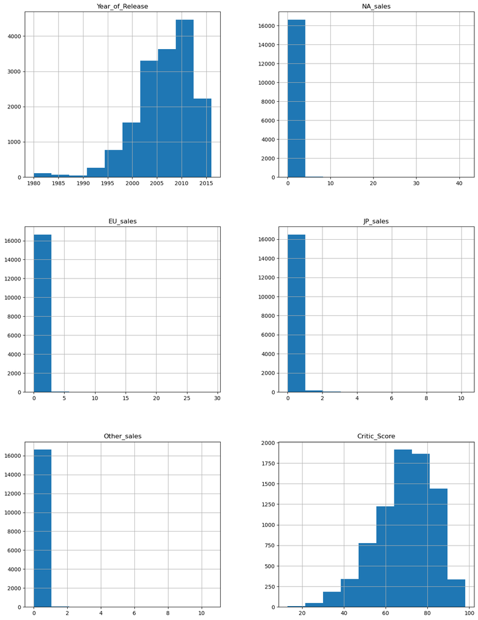

```python
# строим гистограммы для всех числовых столбцов таблицы
data.hist(figsize=(15, 20));
```

```python
# посчитаем суммарное количество пропусков в таблице data
data.isnull().sum()
```

```
Name                  2
Platform              0
Year_of_Release     269
Genre                 2
NA_sales              0
EU_sales              0
JP_sales              0
Other_sales           0
Critic_Score       8578
User_Score         6701
Rating             6766
dtype: int64
```

```python
# посчитаем в процентном отношении пропуски в каждом столбце
data.isna().sum() / len(data)*100
```

```
Name                0.011965
Platform            0.000000
Year_of_Release     1.609333
Genre               0.011965
NA_sales            0.000000
EU_sales            0.000000
JP_sales            0.000000
Other_sales         0.000000
Critic_Score       51.319174
User_Score         40.089740
Rating             40.478612
dtype: float64
```

```python
# посчитаем количество дубликатов
data.duplicated().sum()
```

```
0
```

Необходимо привести к правильному типу столбец : Year of Release Также нужно привести к нижнему регистру столбцы нашей таблицы, а так же сами названия колонок, Имеются пустые значения в столбцах rating, user_score, critic_score. Мы можем заменить имеющиеся пустые значения в таблице: year of release на года от той же игры только другой платформы, в остальных случаях решим в процессе предобработки Дубликатов не имеется

## Подготовим данные

- Заменим названия столбцов (приведем к нижнему регистру);
- Преобразуем данные в нужные типы. Опишем, в каких столбцах заменили тип данных и почему;
- Обработаем пропуски при необходимости:
  - Объясним, почему заполнили пропуски определённым образом или почему не стали это делать;
  - Опишем причины, которые могли привести к пропускам;
  - Обратим внимание на аббревиатуру 'tbd' в столбцах с рейтингом. Отдельно разберем это значение и опишем, как его обработать;
- Посчитаем суммарные продажи во всех регионах и запишем их в отдельный столбец.

### Заменяем названия столбцов (приводим к нижнему регистру)

```python
data.columns
```

```
Index(['Name', 'Platform', 'Year_of_Release', 'Genre', 'NA_sales', 'EU_sales', 'JP_sales', 'Other_sales', 'Critic_Score', 'User_Score', 'Rating'], dtype='object')
```

```python
# приводим к нижнему регистру
data.columns = data.columns.str.lower()
data.columns
```

```
Index(['name', 'platform', 'year_of_release', 'genre', 'na_sales', 'eu_sales', 'jp_sales', 'other_sales', 'critic_score', 'user_score', 'rating'], dtype='object')
```

### Преобразуем данные в нужные типы.

```python
# изменим тип данных в столбце year_of_release
data['year_of_release'] = data['year_of_release'].astype('Int64')
data['year_of_release'].dtype
```

```
Int64Dtype()
```

### Обработаем пропуски при необходимости:

- Объясним, почему заполнили пропуски определённым образом или почему не стали это делать;
- Опишем причины, которые могли привести к пропускам;
- Обратим внимание на аббревиатуру 'tbd' в столбцах с рейтингом. Отдельно разберем это значение и опишем, как его обработать

```python
# удалим пропуски в столбце name
data = data.dropna(subset=['name'])
data = data.reset_index(drop=True)
```

```python
data.info()
```

```
<class 'pandas.core.frame.DataFrame'>
RangeIndex: 16713 entries, 0 to 16712
Data columns (total 11 columns):
 #   Column           Non-Null Count  Dtype
---  ------           --------------  -----
 0   name             16713 non-null  object
 1   platform         16713 non-null  object
 2   year_of_release  16444 non-null  Int64
 3   genre            16713 non-null  object
 4   na_sales         16713 non-null  float64
 5   eu_sales         16713 non-null  float64
 6   jp_sales         16713 non-null  float64
 7   other_sales      16713 non-null  float64
 8   critic_score     8137 non-null   float64
 9   user_score       10014 non-null  object
 10  rating           9949 non-null   object
dtypes: Int64(1), float64(5), object(5)
memory usage: 1.4+ MB
```

```python
# выведем содержимое столбцов с пропусками данных
display(data['year_of_release'].sort_values().unique())
display(data['critic_score'].sort_values().unique())
display(data['user_score'].sort_values().unique())
display(data['rating'].sort_values().unique())
```

```
<IntegerArray>
[1980, 1981, 1982, 1983, 1984, 1985, 1986, 1987, 1988, 1989, 1990, 1991, 1992, 1993, 1994, 1995, 1996, 1997, 1998, 1999, 2000, 2001, 2002, 2003, 2004, 2005, 2006, 2007, 2008, 2009, 2010, 2011, 2012, 2013, 2014, 2015, 2016, <NA>]
Length: 38, dtype: Int64
```

```
array([13., 17., 19., 20., 21., 22., 23., 24., 25., 26., 27., 28., 29.,
       30., 31., 32., 33., 34., 35., 36., 37., 38., 39., 40., 41., 42.,
       43., 44., 45., 46., 47., 48., 49., 50., 51., 52., 53., 54., 55.,
       56., 57., 58., 59., 60., 61., 62., 63., 64., 65., 66., 67., 68.,
       69., 70., 71., 72., 73., 74., 75., 76., 77., 78., 79., 80., 81.,
       82., 83., 84., 85., 86., 87., 88., 89., 90., 91., 92., 93., 94.,
       95., 96., 97., 98., nan])
```

```
array(['0', '0.2', '0.3', '0.5', '0.6', '0.7', '0.9', '1', '1.1', '1.2',
       '1.3', '1.4', '1.5', '1.6', '1.7', '1.8', '1.9', '2', '2.1', '2.2',
       '2.3', '2.4', '2.5', '2.6', '2.7', '2.8', '2.9', '3', '3.1', '3.2',
       '3.3', '3.4', '3.5', '3.6', '3.7', '3.8', '3.9', '4', '4.1', '4.2',
       '4.3', '4.4', '4.5', '4.6', '4.7', '4.8', '4.9', '5', '5.1', '5.2',
       '5.3', '5.4', '5.5', '5.6', '5.7', '5.8', '5.9', '6', '6.1', '6.2',
       '6.3', '6.4', '6.5', '6.6', '6.7', '6.8', '6.9', '7', '7.1', '7.2',
       '7.3', '7.4', '7.5', '7.6', '7.7', '7.8', '7.9', '8', '8.1', '8.2',
       '8.3', '8.4', '8.5', '8.6', '8.7', '8.8', '8.9', '9', '9.1', '9.2',
       '9.3', '9.4', '9.5', '9.6', '9.7', 'tbd', nan], dtype=object)
```

```
array(['AO', 'E', 'E10+', 'EC', 'K-A', 'M', 'RP', 'T', nan], dtype=object)
```

```python
# заменим tbd на Nan
data['user_score'] = data['user_score'].replace('tbd', np.nan, regex=True)
data['user_score'].sort_values().unique()
```

```
array(['0', '0.2', '0.3', '0.5', '0.6', '0.7', '0.9', '1', '1.1', '1.2',
       '1.3', '1.4', '1.5', '1.6', '1.7', '1.8', '1.9', '2', '2.1', '2.2',
       '2.3', '2.4', '2.5', '2.6', '2.7', '2.8', '2.9', '3', '3.1', '3.2',
       '3.3', '3.4', '3.5', '3.6', '3.7', '3.8', '3.9', '4', '4.1', '4.2',
       '4.3', '4.4', '4.5', '4.6', '4.7', '4.8', '4.9', '5', '5.1', '5.2',
       '5.3', '5.4', '5.5', '5.6', '5.7', '5.8', '5.9', '6', '6.1', '6.2',
       '6.3', '6.4', '6.5', '6.6', '6.7', '6.8', '6.9', '7', '7.1', '7.2',
       '7.3', '7.4', '7.5', '7.6', '7.7', '7.8', '7.9', '8', '8.1', '8.2',
       '8.3', '8.4', '8.5', '8.6', '8.7', '8.8', '8.9', '9', '9.1', '9.2',
       '9.3', '9.4', '9.5', '9.6', '9.7', nan], dtype=object)
```

```python
data.info()
```

```
<class 'pandas.core.frame.DataFrame'>
RangeIndex: 16713 entries, 0 to 16712
Data columns (total 11 columns):
 #   Column           Non-Null Count  Dtype
---  ------           --------------  -----
 0   name             16713 non-null  object
 1   platform         16713 non-null  object
 2   year_of_release  16444 non-null  Int64
 3   genre            16713 non-null  object
 4   na_sales         16713 non-null  float64
 5   eu_sales         16713 non-null  float64
 6   jp_sales         16713 non-null  float64
 7   other_sales      16713 non-null  float64
 8   critic_score     8137 non-null   float64
 9   user_score       7590 non-null   object
 10  rating           9949 non-null   object
dtypes: Int64(1), float64(5), object(5)
memory usage: 1.4+ MB
```

```python
data.isna().sum()/len(data)*100
```

```
name                0.000000
platform            0.000000
year_of_release     1.609526
genre               0.000000
na_sales            0.000000
eu_sales            0.000000
jp_sales            0.000000
other_sales         0.000000
critic_score       51.313349
user_score         54.586250
rating             40.471489
dtype: float64
```

Обратим внимание на аббревиатуру tbd в столбце с оценкой пользователей. Аббревиатура 'tbd' значит "to be determined, to be done". То есть, данные были нарочно не заполнены, так как не определились с рейтингом. Поэтому предлагаю заменить 'tbd' на Nan.

```python
# поменяем формат столбца user_score на float
data['user_score'] = data['user_score'].astype(float)
data['user_score'].dtype
```

```
dtype('float64')
```

```python
# первоначально "K-A" ("Kids to Adults") -это 'E'
data['rating'].sort_values().unique()
```

```
array(['AO', 'E', 'E10+', 'EC', 'K-A', 'M', 'RP', 'T', nan], dtype=object)
```

```python
# меняем "K-A" ("Kids to Adults") на 'E'
data['rating'] = data['rating'].replace('K-A', 'E')
data['rating'].sort_values().unique()
```

```
array(['AO', 'E', 'E10+', 'EC', 'M', 'RP', 'T', nan], dtype=object)
```

```python
#заменяем пропуски заглушкой(-1) в столбце critic_score
data['critic_score'] = data['critic_score'].fillna(-1)
```

```python
# заменяем пропуски заглушкой(-1) в столбце user_score
data['user_score'] = data['user_score'].fillna(-1)
```

```python
# заменяем пропуски заглушкой(-1) в столбце rating
data['rating'] = data['rating'].fillna('unknown')
```

```python
# удалим пропуски в столбце year_of_release
data = data.dropna(subset=['year_of_release']).reset_index(drop=True)
```

```python
# создаем новый столбец rating_game для информативности рейтинга
def rating_game(rating):
    try:
        if rating == 'EC':
            return 'Для детей младшего возраста'
        elif rating == 'E':
            return 'Для всех'
        elif rating == 'E10+':
            return 'Для всех от 10 лет и старше'
        elif rating == 'T':
            return 'Подросткам'
        elif rating == 'M':
            return 'Для взрослых'
        elif rating == 'AO':
            return 'Только для взрослых'
        elif rating == 'RP':
            return 'Рейтинг ожидается'
    except:
        pass
data['rating_game'] = data['rating'].apply(rating_game)
```

```python
# заменяем пропуски заглушкой(unknown) в столбце rating_game
data['rating_game'] = data['rating_game'].fillna('unknown')
```

### Посчитайте суммарные продажи во всех регионах и запишите их в отдельный столбец

```python
data['total_sale'] = data['na_sales'] + data['eu_sales']+ data['jp_sales']+ data['other_sales']
```

На данном этапе были проведены замены названий столбцов на более удобные для дальнейшей работы, а также проведена работа по поиску и замене пропущенных значений.

Нам встретились пропущенные значения в столбцах name, year_of_release, , genre, critic_score, user_score и rating.

В столбце name, genre было всего два пропуска, что не является критичным и может быть вызвано случайностью.

В столбце year_of_release данные с пропусками были удалены, т.к. пропуски сотавляли всего 1,6% от всех данных. Причина образования пропусков человеческий фактор, т.е. случайным образом. Перевели в тип данных integer.

В столбце user_score заменили аббревиатуру tbd на Nan, перевели в тип данных float64. Пропуски значений critic_score и user_score составляют порядка половины данных и часто встречаются вместе. С большой вероятностью это говорит нам о том, что оценки для части игр не были выставлены или же просто не были загружены в таблицу. Пропуски в столбцах заполняем заглушками.

В столбце rating заменили устаревшее название "K-A" ("Kids to Adults") на 'E'. В столбце rating пропуски в основном встречаются с 1980 по 1995 годах, потому что данная организация ESRB была создана в 1996 году. Второй причиной пропусков могут быть новые игры, которые еще не успели агрегировать оценки критиков и пользователей.Поэтому пропуски в столбце rating заполняем заглушкой. Для информативности рейтинга создаем новый столбец rating_game и заполняем пропуски также как в столбце rating, заглушкой.

Так же были посчитаны суммарные продажи во всех регионах с последующим сохранением значений в отдельный столбец 'total_sales'.

Данные подготовлены к дальнейшему анализу.

```python
# Посмотрим, что у нас осталось
temp = data.copy()
list_c = ['name', 'platform', 'year_of_release', 'genre', 'critic_score', 'user_score', 'rating', 'rating_game']
print(temp.info())
for col_l in list_c:
  print('-'* 25)
  print(col_l, temp[col_l].unique())
  print(col_l,': кол-во NaN',temp[col_l].isna().sum(),
        ', процент NaN', round(temp[col_l].isna().sum()/len(temp)*100, 2),'%')
```

```
<class 'pandas.core.frame.DataFrame'>
RangeIndex: 16444 entries, 0 to 16443
Data columns (total 13 columns):
 #   Column           Non-Null Count  Dtype
---  ------           --------------  -----
 0   name             16444 non-null  object
 1   platform         16444 non-null  object
 2   year_of_release  16444 non-null  Int64
 3   genre            16444 non-null  object
 4   na_sales         16444 non-null  float64
 5   eu_sales         16444 non-null  float64
 6   jp_sales         16444 non-null  float64
 7   other_sales      16444 non-null  float64
 8   critic_score     16444 non-null  float64
 9   user_score       16444 non-null  float64
 10  rating           16444 non-null  object
 11  rating_game      16444 non-null  object
 12  total_sale       16444 non-null  float64
dtypes: Int64(1), float64(7), object(5)
memory usage: 1.6+ MB
None
-------------------------
name ['Wii Sports' 'Super Mario Bros.' 'Mario Kart Wii' ...
 'Woody Woodpecker in Crazy Castle 5' 'LMA Manager 2007'
 'Haitaka no Psychedelica']
name : кол-во NaN 0 , процент NaN 0.0 %
-------------------------
platform ['Wii' 'NES' 'GB' 'DS' 'X360' 'PS3' 'PS2' 'SNES' 'GBA' 'PS4' '3DS' 'N64'
 'PS' 'XB' 'PC' '2600' 'PSP' 'XOne' 'WiiU' 'GC' 'GEN' 'DC' 'PSV' 'SAT'
 'SCD' 'WS' 'NG' 'TG16' '3DO' 'GG' 'PCFX']
platform : кол-во NaN 0 , процент NaN 0.0 %
-------------------------
year_of_release <IntegerArray>
[2006, 1985, 2008, 2009, 1996, 1989, 1984, 2005, 1999, 2007, 2010, 2013, 2004, 1990, 1988, 2002, 2001, 2011, 1998, 2015, 2012, 2014, 1992, 1997, 1993, 1994, 1982, 2016, 2003, 1986, 2000, 1995, 1991, 1981, 1987, 1980, 1983]
Length: 37, dtype: Int64
year_of_release : кол-во NaN 0 , процент NaN 0.0 %
-------------------------
genre ['Sports' 'Platform' 'Racing' 'Role-Playing' 'Puzzle' 'Misc' 'Shooter'
 'Simulation' 'Action' 'Fighting' 'Adventure' 'Strategy']
genre : кол-во NaN 0 , процент NaN 0.0 %
```

[output cut: 9 more lines]

```
  8.7  7.1  3.4  5.3  4.8  3.2  8.9  6.4  7.8  7.5  2.6  7.2  9.2  7.
  7.3  4.3  7.6  5.7  5.   9.1  6.5  8.8  6.9  9.4  6.8  6.1  6.7  5.4
  4.   4.9  4.5  9.3  6.2  4.2  6.   3.7  4.1  5.8  5.6  5.5  4.4  4.6
  5.9  3.9  3.1  2.9  5.2  3.3  4.7  5.1  3.5  2.5  1.9  3.   2.7  2.2
  2.   9.5  2.1  3.6  2.8  1.8  3.8  0.   1.6  9.6  2.4  1.7  1.1  0.3
  1.5  0.7  1.2  2.3  0.5  1.3  0.2  0.6  1.4  0.9  1.   9.7]
user_score : кол-во NaN 0 , процент NaN 0.0 %
-------------------------
rating ['E' 'unknown' 'M' 'T' 'E10+' 'AO' 'EC' 'RP']
rating : кол-во NaN 0 , процент NaN 0.0 %
-------------------------
rating_game ['Для всех' 'unknown' 'Для взрослых' 'Подросткам'
 'Для всех от 10 лет и старше' 'Только для взрослых'
 'Для детей младшего возраста' 'Рейтинг ожидается']
rating_game : кол-во NaN 0 , процент NaN 0.0 %
```

## Исследовательский анализ данных

- Посмотрим, сколько игр выпускалось в разные годы. Важны ли данные за все периоды?
- Посмотрим, как менялись продажи по платформам. Выберите платформы с наибольшими суммарными продажами и постройте распределение по годам. За какой характерный срок появляются новые и исчезают старые платформы?
- Возьмем данные за соответствующий актуальный период. Актуальный период определим самостоятельно в результате исследования предыдущих вопросов. Основной фактор — эти данные помогут построить прогноз на 2017 год.
- Не учитываем в работе данные за предыдущие годы.
- Какие платформы лидируют по продажам, растут или падают? Выберем несколько потенциально прибыльных платформ.
- Построим график «ящик с усами» по глобальным продажам игр в разбивке по платформам. Опишите результат.
- Посмотрим, как влияют на продажи внутри одной популярной платформы отзывы пользователей и критиков. Построим диаграмму рассеяния и посчитаем корреляцию между отзывами и продажами. Сформулируем выводы.
- Соотнесем выводы с продажами игр на других платформах.
- Посмотрим на общее распределение игр по жанрам. Что можно сказать о самых прибыльных жанрах? Выделяются ли жанры с высокими и низкими продажами?

### Посмотрим, сколько игр выпускалось в разные годы. Важны ли данные за все периоды?

```python
#группируем данные по столбцам year_of_release и name
data_year_of_release_name_g = data.groupby('year_of_release', as_index=False)['name'].count()
data_year_of_release_name_g
```

|  | year_of_release | name |
| --- | --- | --- |
| 0 | 1980 | 9 |
| 1 | 1981 | 46 |
| 2 | 1982 | 36 |
| 3 | 1983 | 17 |
| 4 | 1984 | 14 |
| 5 | 1985 | 14 |
| 6 | 1986 | 21 |
| 7 | 1987 | 16 |
| 8 | 1988 | 15 |
| 9 | 1989 | 17 |
| 10 | 1990 | 16 |
| 11 | 1991 | 41 |
| 12 | 1992 | 43 |
| 13 | 1993 | 60 |
| 14 | 1994 | 121 |
| 15 | 1995 | 219 |
| 16 | 1996 | 263 |
| 17 | 1997 | 289 |
| 18 | 1998 | 379 |
| 19 | 1999 | 338 |
| 20 | 2000 | 350 |
| 21 | 2001 | 482 |
| 22 | 2002 | 829 |
| 23 | 2003 | 775 |
| 24 | 2004 | 762 |
| 25 | 2005 | 939 |
| 26 | 2006 | 1006 |
| 27 | 2007 | 1197 |
| 28 | 2008 | 1427 |
| 29 | 2009 | 1426 |
| 30 | 2010 | 1255 |
| 31 | 2011 | 1136 |
| 32 | 2012 | 653 |
| 33 | 2013 | 544 |
| 34 | 2014 | 581 |
| 35 | 2015 | 606 |
| 36 | 2016 | 502 |

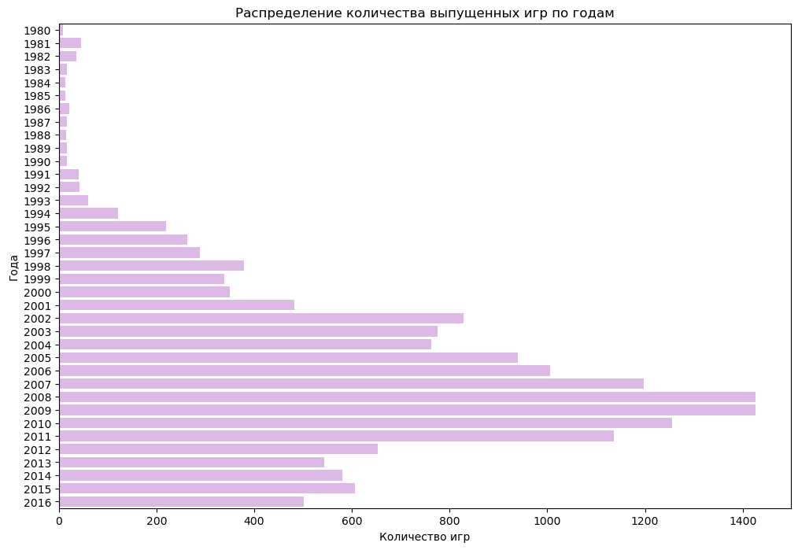

```python
# строим график распределение количества выпущенных игр по годам
plt.figure(figsize=(12, 8));
ax=sns.barplot(y=data_year_of_release_name_g.year_of_release,\
               x=data_year_of_release_name_g.name, \
               orient='h', color='#e2b2ed');

plt.xlabel('Количество игр')
plt.ylabel('Года')
plt.title('Распределение количества выпущенных игр по годам');
```

Данные за все периоды не нужны. Очень мало игр было выпущено за период с 1980 г. по 1994 г. Больше всего игр было выпущено в 2008-2009 года. Начиная с 2010 заметен спад продаж игр нового поколения консолей, который привёл к сокращению потенциального рынка сбыта.

### Выбираем платформы с наибольшими суммарными продажами и построим графики распределения по годам.

```python
#группируем данные по столбцам year_of_release и name
data_plt_year = data.groupby('platform', as_index=False)['total_sale'].agg('sum').sort_values('total_sale', ascending=False)
data_plt_year.head(6)
```

|  | platform | total_sale |
| --- | --- | --- |
| 16 | PS2 | 1233.56 |
| 28 | X360 | 961.24 |
| 17 | PS3 | 931.34 |
| 26 | Wii | 891.18 |
| 4 | DS | 802.78 |
| 15 | PS | 727.58 |

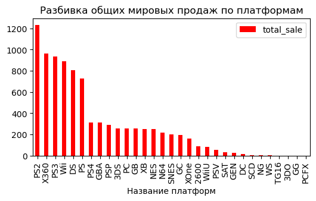

```python
# строим график с разбивкой общих мировых продаж по платформам
plt.figure(figsize=(12, 8))

data_plt_year.plot(x='platform',
               y='total_sale',
               kind='bar',
               figsize=(6, 3),
               title='Разбивка общих мировых продаж по платформам',
               color='#FF0000');

plt.xlabel('Название платформ');
```

```python
data['platform'].unique()
```

```
array(['Wii', 'NES', 'GB', 'DS', 'X360', 'PS3', 'PS2', 'SNES', 'GBA',
       'PS4', '3DS', 'N64', 'PS', 'XB', 'PC', '2600', 'PSP', 'XOne',
       'WiiU', 'GC', 'GEN', 'DC', 'PSV', 'SAT', 'SCD', 'WS', 'NG', 'TG16',
       '3DO', 'GG', 'PCFX'], dtype=object)
```

Топ-6 платформ являются главными претендентами для детального дальнейшего анализа по общим мировым продажам: PS2, X360, PS3, Wii, DS, PS.

```python
# выбираем платформы с общими мировыми продажами больше 700
platforms_median = []
for row in data_plt_year.itertuples():
    if row.total_sale > 700:
        platforms_median.append(row.platform)
platforms_median
```

```
['PS2', 'X360', 'PS3', 'Wii', 'DS', 'PS']
```

[figure not shown]

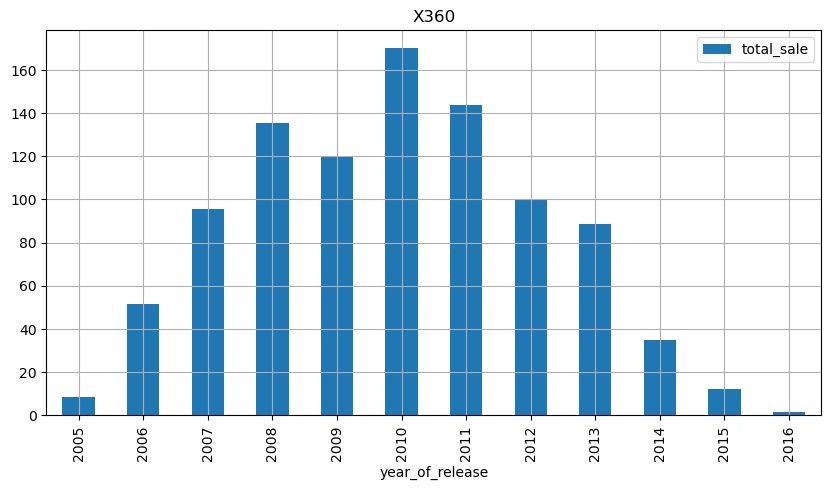

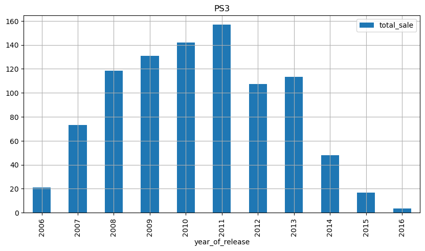

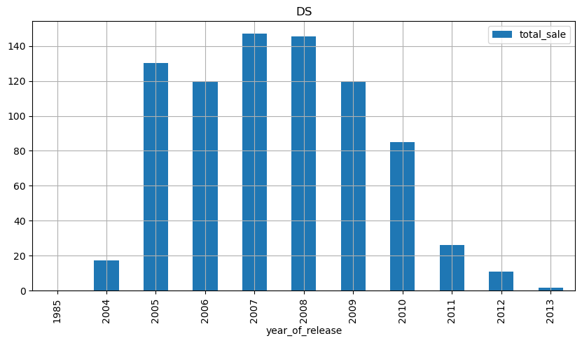

[figure not shown]

[figure not shown]

```python
# создание гистограмм суммарных продаж по годам для 6 самых популярных платформ.
(data
    .query('platform=="PS2"')
    .pivot_table(index='year_of_release', values='total_sale', aggfunc=sum)
    .plot(grid=True, kind='bar',figsize=(10, 5))
)
plt.title('PS2') # присвоение заголовка гистограмме
plt.figtext(0.2, -0.1, "Рис.1. - Гистограмм суммарных продаж PS2 по годам для 5 самых популярных платформ")
(data
    .query('platform=="X360"')
    .pivot_table(index='year_of_release', values='total_sale', aggfunc=sum)
    .plot(grid=True, kind='bar',figsize=(10, 5))
)
plt.title('X360')
(data
    .query('platform=="PS3"')
    .pivot_table(index='year_of_release', values='total_sale', aggfunc=sum)
    .plot(grid=True, kind='bar',figsize=(10, 5))
)
plt.title('PS3')
(data
    .query('platform=="DS"')
    .pivot_table(index='year_of_release', values='total_sale', aggfunc=sum)
    .plot(grid=True, kind='bar',figsize=(10, 5))
)
plt.title('DS')
(data
    .query('platform=="Wii"')
    .pivot_table(index='year_of_release', values='total_sale', aggfunc=sum)
    .plot(grid=True, kind='bar',figsize=(10, 5))
)
plt.title('PS')
(data
    .query('platform=="PS"')
    .pivot_table(index='year_of_release', values='total_sale', aggfunc=sum)
    .plot(grid=True, kind='bar',figsize=(10, 5))
)
plt.title('Wii')
```

```python
# группировка данных по годам и платформам и подсчет суммарных мировых продаж
sales_year = data.query('platform in @platforms_median') \
    .groupby(['year_of_release', 'platform'], as_index=False) \
    .agg({'total_sale': 'sum'}) \
    .sort_values('total_sale', ascending=True)
sales_year.head()
```

|  | year_of_release | platform | total_sale |
| --- | --- | --- | --- |
| 0 | 1985 | DS | 0.02 |
| 65 | 2016 | Wii | 0.18 |
| 46 | 2011 | PS2 | 0.45 |
| 62 | 2015 | Wii | 1.14 |
| 66 | 2016 | X360 | 1.52 |

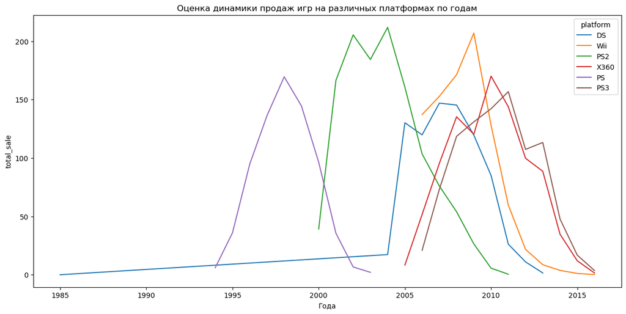

```python
# строим график оценки динамики продаж игр на различных платформах по годам
plt.figure(figsize=(15, 7));

sns.lineplot(x=sales_year.year_of_release,
             y=sales_year.total_sale,
             hue=sales_year.platform);

plt.xlabel('Года');

plt.title('Оценка динамики продаж игр на различных платформах по годам');
```

Платформа DS в 1985 году не существовала, она появилась только в 2004 году. В данных она строка(15704) с названием игры Strongest Tokyo University Shogi DS. Поэтому принимаем решения удалить данную строку, чтобы не искажала данные по платформе DS.

```python
# выводим данные о платформе DS до 2004 года.
data[(data['platform'] == 'DS') & (data['year_of_release'] <= 2003)]
```

|  | name | platform | year_of_release | genre | na_sales | eu_sales | jp_sales | other_sales | critic_score | user_score | rating | rating_game | total_sale |
| --- | --- | --- | --- | --- | --- | --- | --- | --- | --- | --- | --- | --- | --- |
| 15704 | Strongest Tokyo University Shogi DS | DS | 1985 | Action | 0.0 | 0.0 | 0.02 | 0.0 | -1.0 | -1.0 | unknown | unknown | 0.02 |

```python
# удаляем строку платформы DS, т.к. строка дает искаженные данные
data.drop(labels = [15704],axis = 0, inplace=True)
```

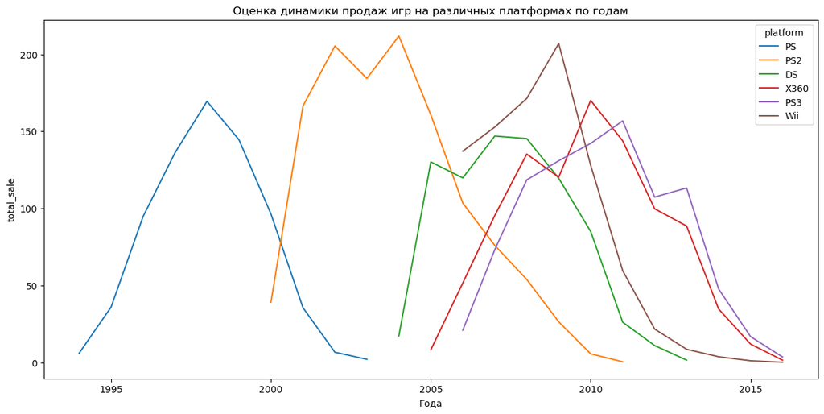

```python
# группировка данных по годам и платформам и подсчет суммарных мировых продаж
sales_year1 = data.query('platform in @platforms_median') \
    .groupby(['year_of_release', 'platform'], as_index=False) \
    .agg({'total_sale': 'sum'}) \
    .sort_values('year_of_release', ascending=True)
# строим  новый график оценки динамики продаж игр на различных платформах по годам
plt.figure(figsize=(15, 7));

sns.lineplot(x=sales_year1.year_of_release,
             y=sales_year1.total_sale,
             hue=sales_year1.platform);

plt.xlabel('Года');

plt.title('Оценка динамики продаж игр на различных платформах по годам');
```

После удаления строки с неправильными данными по платформе DS, график стал выглядеть правдоподобно. Средний возраст действия платформы 6-7 лет.

```python
# посчитаем продолжительность жизни платформы
term_platform = data.groupby('platform').year_of_release.max() - data.groupby('platform').year_of_release.min()
term_platform
```

```
platform
2600     9
3DO      1
3DS      5
DC      10
DS       9
GB      13
GBA      7
GC       6
GEN      4
GG       0
N64      6
NES     11
NG       3
PC      31
PCFX     0
PS       9
PS2     11
PS3     10
PS4      3
PSP     11
PSV      5
SAT      5
SCD      1
SNES     9
TG16     0
WS       2
Wii     10
WiiU     4
X360    11
XB       8
XOne     3
Name: year_of_release, dtype: Int64
```

```python
# основные статистики продолжительности жизненного цикла платформ
term_platform.describe()
```

```
count    31.000000
mean      7.000000
std       5.899152
min       0.000000
25%       3.000000
50%       6.000000
75%      10.000000
max      31.000000
Name: year_of_release, dtype: float64
```

```python
# группируема данные платформ за последние 5 лет по годам и платформам и подсчет суммарных мировых продаж
data['year_of_release'] = data['year_of_release'].astype('float')
platform_5year = data.query('year_of_release > 2011') \
    .groupby(['year_of_release', 'platform'], as_index=False) \
    .agg({'total_sale': 'sum'}) \
    .sort_values('year_of_release', ascending=True)
platform_5year
```

|  | year_of_release | platform | total_sale |
| --- | --- | --- | --- |
| 0 | 2012.0 | 3DS | 51.36 |
| 1 | 2012.0 | DS | 11.01 |
| 2 | 2012.0 | PC | 23.22 |
| 3 | 2012.0 | PS3 | 107.36 |
| 4 | 2012.0 | PSP | 7.69 |
| 5 | 2012.0 | PSV | 16.19 |
| 6 | 2012.0 | Wii | 21.71 |
| 7 | 2012.0 | WiiU | 17.56 |
| 8 | 2012.0 | X360 | 99.74 |
| 19 | 2013.0 | XOne | 18.96 |
| 18 | 2013.0 | X360 | 88.58 |
| 17 | 2013.0 | WiiU | 21.65 |
| 16 | 2013.0 | Wii | 8.59 |
| 15 | 2013.0 | PSV | 10.59 |
| 12 | 2013.0 | PS3 | 113.25 |
| 13 | 2013.0 | PS4 | 25.99 |
| 11 | 2013.0 | PC | 12.38 |
| 10 | 2013.0 | DS | 1.54 |
| 9 | 2013.0 | 3DS | 56.57 |
| 14 | 2013.0 | PSP | 3.14 |
| 26 | 2014.0 | Wii | 3.75 |
| 29 | 2014.0 | XOne | 54.07 |
| 28 | 2014.0 | X360 | 34.74 |
| 27 | 2014.0 | WiiU | 22.03 |
| 25 | 2014.0 | PSV | 11.90 |
| 24 | 2014.0 | PSP | 0.24 |
| 23 | 2014.0 | PS4 | 100.00 |
| 22 | 2014.0 | PS3 | 47.76 |
| 21 | 2014.0 | PC | 13.28 |
| 20 | 2014.0 | 3DS | 43.76 |
| 39 | 2015.0 | XOne | 60.14 |
| 38 | 2015.0 | X360 | 11.96 |
| 36 | 2015.0 | Wii | 1.14 |
| 35 | 2015.0 | PSV | 6.25 |
| 37 | 2015.0 | WiiU | 16.35 |
| 33 | 2015.0 | PS4 | 118.90 |
| 32 | 2015.0 | PS3 | 16.82 |
| 31 | 2015.0 | PC | 8.52 |
| 30 | 2015.0 | 3DS | 27.78 |
| 34 | 2015.0 | PSP | 0.12 |
| 47 | 2016.0 | X360 | 1.52 |
| 40 | 2016.0 | 3DS | 15.14 |
| 41 | 2016.0 | PC | 5.25 |
| 42 | 2016.0 | PS3 | 3.60 |
| 43 | 2016.0 | PS4 | 69.25 |
| 44 | 2016.0 | PSV | 4.25 |
| 45 | 2016.0 | Wii | 0.18 |
| 46 | 2016.0 | WiiU | 4.60 |
| 48 | 2016.0 | XOne | 26.15 |

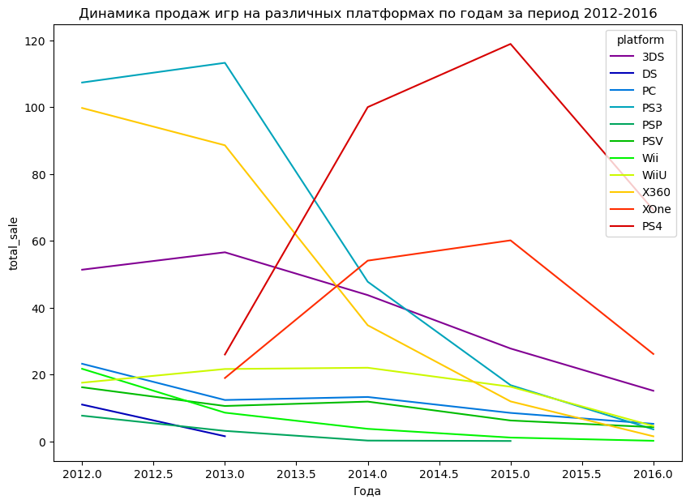

```python
# строим график динамики продаж игр на различных платформах по годам за период 2012-2016
plt.figure(figsize=(10, 7))

sns.lineplot(x=platform_5year.year_of_release,
             y=platform_5year.total_sale,
             hue=platform_5year.platform,
             legend='full',
             palette='nipy_spectral');

plt.xlabel('Года');

plt.title('Динамика продаж игр на различных платформах по годам за период 2012-2016');
```

Лидерами в продажи игр на 2017 г. остаются три платформы: PS4 и Xbox One. Остатки популярности имеются у Nintendo 3DS. Остальные платфоры в продажи игр к 2017 г. стремятся к нулю.

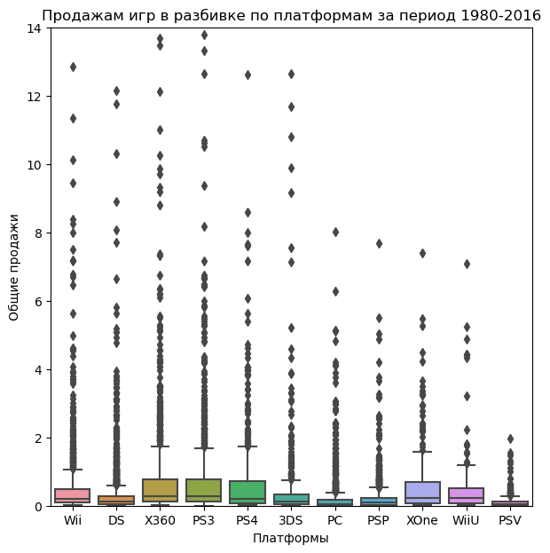

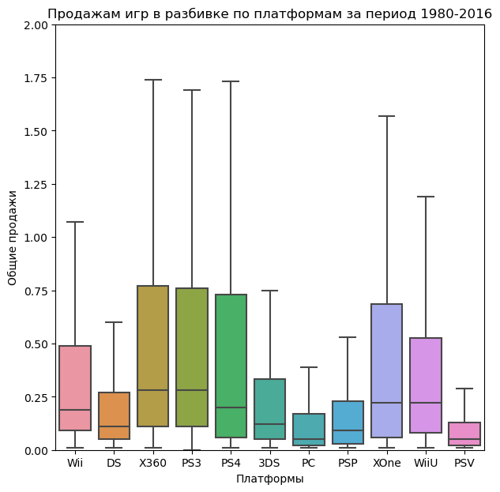

```python
# продажи за период по плтформам 1980-2016 г.
popular_platforms_all = ['PS4', 'XOne', '3DS', 'DS', 'PC', 'PS3', 'PSP', 'PSV', 'Wii', 'WiiU', 'X360']
data_platforms_year = data.query('platform in @popular_platforms_all').reset_index(drop=True)

plt.figure(figsize=(7,7))
ax=sns.boxplot(x ='platform', y = 'total_sale', data=data_platforms_year)
plt.xlabel('Платформы');
plt.ylabel('Общие продажи');
ax.set(ylim=(0, 14))
plt.title('Продажам игр в разбивке по платформам за период 1980-2016');
plt.figure(figsize=(7,7))
ax1=sns.boxplot(x ='platform', y = 'total_sale', data=data_platforms_year, showfliers = False)
plt.xlabel('Платформы');
plt.ylabel('Общие продажи');
ax1.set(ylim=(0, 2))
plt.title('Продажам игр в разбивке по платформам за период 1980-2016');
```

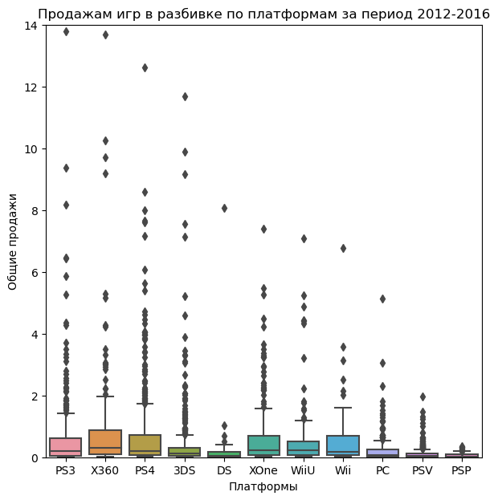

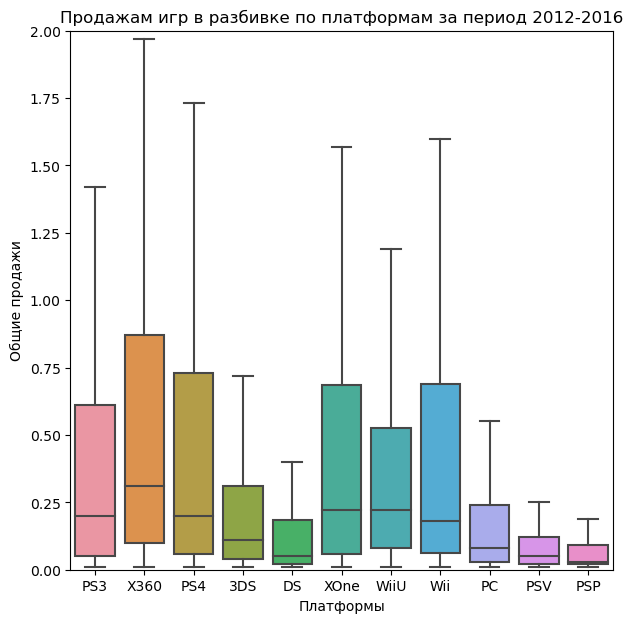

```python
# продажи за период 2012-2016 гг.
popular_platforms_all = ['PS4', 'XOne', '3DS', 'DS', 'PC', 'PS3', 'PSP', 'PSV', 'Wii', 'WiiU', 'X360']
data_platforms_all2011 = data.query('platform in @popular_platforms_all & year_of_release > 2011').reset_index(drop=True)

plt.figure(figsize=(7,7))
ax=sns.boxplot (x = 'platform', y = 'total_sale', data = data_platforms_all2011)


plt.xlabel('Платформы');
plt.ylabel('Общие продажи');
plt.title('Продажам игр в разбивке по платформам за период 2012-2016');
ax.set(ylim=(0, 14))

plt.figure(figsize=(7,7))
ax1=sns.boxplot (x = 'platform', y = 'total_sale', data = data_platforms_all2011, showfliers = False)
ax1.set(ylim=(0, 2))

plt.xlabel('Платформы');
plt.ylabel('Общие продажи');
plt.title('Продажам игр в разбивке по платформам за период 2012-2016');
```

```python
# получение описательных статистик
data_platforms_all2011.groupby(['platform']).total_sale.describe()
```

| platform | count | mean | std | min | 25% | 50% | 75% | max |
| --- | --- | --- | --- | --- | --- | --- | --- | --- |
| 3DS | 396.0 | 0.491439 | 1.387161 | 0.01 | 0.0400 | 0.11 | 0.3125 | 14.60 |
| DS | 31.0 | 0.404839 | 1.439245 | 0.01 | 0.0200 | 0.05 | 0.1850 | 8.06 |
| PC | 250.0 | 0.250600 | 0.494640 | 0.01 | 0.0300 | 0.08 | 0.2400 | 5.14 |
| PS3 | 493.0 | 0.585781 | 1.462855 | 0.01 | 0.0500 | 0.20 | 0.6100 | 21.05 |
| PS4 | 392.0 | 0.801378 | 1.609456 | 0.01 | 0.0600 | 0.20 | 0.7300 | 14.63 |
| PSP | 173.0 | 0.064682 | 0.071296 | 0.01 | 0.0200 | 0.03 | 0.0900 | 0.36 |
| PSV | 411.0 | 0.119659 | 0.203011 | 0.01 | 0.0200 | 0.05 | 0.1200 | 1.96 |
| Wii | 54.0 | 0.655000 | 1.165447 | 0.01 | 0.0625 | 0.18 | 0.6875 | 6.76 |
| WiiU | 147.0 | 0.559116 | 1.058836 | 0.01 | 0.0800 | 0.22 | 0.5250 | 7.09 |
| X360 | 292.0 | 0.810068 | 1.712069 | 0.01 | 0.1000 | 0.31 | 0.8700 | 16.27 |
| XOne | 247.0 | 0.645020 | 1.036139 | 0.01 | 0.0600 | 0.22 | 0.6850 | 7.39 |

Найдем игру с максимальными мировыми продажами для каждой из платформ.

```python
# отбираем индексы
data_platforms_all2011.groupby(['platform']).total_sale.idxmax()
```

```
platform
3DS       3
DS       16
PC       39
PS3       0
PS4       2
PSP     818
PSV     154
Wii      25
WiiU     24
X360      1
XOne     21
Name: total_sale, dtype: int64
```

```python
# выводим наиболее продаваемые игры по отобранным индексам
data_platforms_all2011.iloc[[0, 1, 2, 16, 21, 24, 25, 39]]
```

|  | name | platform | year_of_release | genre | na_sales | eu_sales | jp_sales | other_sales | critic_score | user_score | rating | rating_game | total_sale |
| --- | --- | --- | --- | --- | --- | --- | --- | --- | --- | --- | --- | --- | --- |
| 0 | Grand Theft Auto V | PS3 | 2013.0 | Action | 7.02 | 9.09 | 0.98 | 3.96 | 97.0 | 8.2 | M | Для взрослых | 21.05 |
| 1 | Grand Theft Auto V | X360 | 2013.0 | Action | 9.66 | 5.14 | 0.06 | 1.41 | 97.0 | 8.1 | M | Для взрослых | 16.27 |
| 2 | Call of Duty: Black Ops 3 | PS4 | 2015.0 | Shooter | 6.03 | 5.86 | 0.36 | 2.38 | -1.0 | -1.0 | unknown | unknown | 14.63 |
| 16 | Pokemon Black 2/Pokemon White 2 | DS | 2012.0 | Role-Playing | 2.79 | 1.72 | 3.14 | 0.41 | -1.0 | -1.0 | unknown | unknown | 8.06 |
| 21 | Call of Duty: Black Ops 3 | XOne | 2015.0 | Shooter | 4.59 | 2.11 | 0.01 | 0.68 | -1.0 | -1.0 | unknown | unknown | 7.39 |
| 24 | Mario Kart 8 | WiiU | 2014.0 | Racing | 3.15 | 2.15 | 1.28 | 0.51 | 88.0 | 9.1 | E | Для всех | 7.09 |
| 25 | Just Dance 4 | Wii | 2012.0 | Misc | 4.05 | 2.16 | 0.00 | 0.55 | 74.0 | 7.3 | E10+ | Для всех от 10 лет и старше | 6.76 |
| 39 | Diablo III | PC | 2012.0 | Role-Playing | 2.44 | 2.16 | 0.00 | 0.54 | 88.0 | 4.0 | M | Для взрослых | 5.14 |

Для платформ PS3, X360 наиболее продаваемой игрой стала 'Grand Theft Auto V' - 2013 года выпуска. Для платформ PS4 наиболее продаваемой игрой стала 'Call of Duty: Black Ops 3' - 2015 года выпуска. Для платформ 3DS наиболее продаваемой игрой стала 'Pokemon X/Pokemon Y' - 2013 года выпуска. Для платформ DS наиболее продаваемой игрой стала 'Pokemon Black 2/Pokemon White 2' - 2012 года выпуска. Для платформ XOne наиболее продаваемой игрой стала 'Call of Duty: Black Ops 3' - 2015 года выпуска. Для платформ WiiU наиболее продаваемой игрой стала 'Mario Kart 8' - 2014 года выпуска.

Посмотрим, как влияют на продажи внутри одной популярной платформы отзывы пользователей и критиков. Построим диаграммы рассеивания и посчитаем коэффициенты корреляции между отзывами и продажами.

```python
# делаем срез данных по названию платформы X360
data_critic_score_x360 = data_platforms_all2011.query('platform == "X360" & critic_score >-1')
data_user_score_x360 = data_platforms_all2011.query('platform == "X360" &  user_score >-1')

# делаем срез данных по названию платформы PS3
data_critic_score_ps3 = data_platforms_all2011.query('platform == "PS3" & critic_score >-1')
data_user_score_ps3 = data_platforms_all2011.query('platform == "PS3"  & user_score >-1')

# делаем срез данных по названию платформы PS4
data_critic_score_ps4 = data_platforms_all2011.query('platform == "PS4" & critic_score >-1')
data_user_score_ps4 = data_platforms_all2011.query('platform == "PS4" & user_score >-1')

# делаем срез данных по названию платформы 3DS
data_critic_score_3ds = data_platforms_all2011.query('platform == "3DS" & critic_score >-1')
data_user_score_3ds = data_platforms_all2011.query('platform == "3DS" & user_score >-1')

# делаем срез данных по названию платформы XOne
data_critic_score_x0ne = data_platforms_all2011.query('platform == "XOne" & critic_score >-1')
data_user_score_x0ne = data_platforms_all2011.query('platform == "XOne" &  user_score >-1')

# делаем срез данных по названию платформы WiiU
data_critic_score_wiiu = data_platforms_all2011.query('platform == "WiiU" & critic_score >-1')
data_user_score_wiiu = data_platforms_all2011.query('platform == "WiiU" & user_score >-1')
```

**Платформа - X360**

```python
len(data_critic_score_x360)
```

```
171
```

```python
len(data_user_score_x360)
```

```
235
```

```python
len(data_platforms_all2011.query('platform == "X360" & critic_score >-1 & user_score >-1'))
```

```
171
```

```python
data_critic_score_x360['total_sale'].corr(data_critic_score_x360['critic_score'])
```

```
0.36057348885073365
```

```python
data_critic_score_x360['total_sale'].mean()
```

```
1.058187134502924
```

```python
data_user_score_x360['total_sale'].corr(data_user_score_x360['user_score'])
```

```
0.0061639786462133256
```

**Платформа - PS3**

```python
len(data_critic_score_ps3)
```

```
214
```

```python
len(data_user_score_ps3)
```

```
283
```

```python
len(data_platforms_all2011.query('platform == "PS3"  & user_score >-1 & critic_score >-1'))
```

```
213
```

```python
data_critic_score_ps3['total_sale'].corr(data_critic_score_ps3['critic_score'])
```

```
0.3314972592629587
```

```python
data_user_score_ps3['total_sale'].corr(data_user_score_ps3['user_score'])
```

```
-0.005143522887113816
```

**Платформа - PS4**

```python
len(data_critic_score_ps4)
```

```
252
```

```python
len(data_user_score_ps4)
```

```
257
```

```python
len(data_platforms_all2011.query('platform == "PS4" & critic_score >-1 & user_score >-1'))
```

```
249
```

```python
data_critic_score_ps4['total_sale'].corr(data_critic_score_ps4['critic_score'])
```

```
0.406567902061781
```

```python
data_user_score_ps4['total_sale'].corr(data_user_score_ps4['user_score'])
```

```
-0.031957110204556424
```

**Платформа - 3DS**

```python
len(data_critic_score_3ds)
```

```
104
```

```python
len(data_user_score_3ds)
```

```
114
```

```python
len(data_user_score_wiiu)
```

```
100
```

```python
len(data_platforms_all2011.query('platform == "WiiU" & critic_score >-1 & user_score >-1'))
```

```
89
```

```python
data_critic_score_3ds['total_sale'].corr(data_critic_score_3ds['critic_score'])
```

```
0.32080286953607845
```

```python
data_user_score_3ds['total_sale'].corr(data_user_score_3ds['user_score'])
```

```
0.19758263411038596
```

**Платформа - XOne**

```python
len(data_critic_score_x0ne)
```

```
169
```

```python
len(data_user_score_x0ne)
```

```
182
```

```python
len(data_platforms_all2011.query('platform == "XOne" & critic_score >-1 & user_score >-1'))
```

```
165
```

```python
data_critic_score_x0ne['total_sale'].corr(data_critic_score_x0ne['critic_score'])
```

```
0.41699832800840175
```

```python
data_user_score_x0ne['total_sale'].corr(data_user_score_x0ne['user_score'])
```

```
-0.06892505328279412
```

**Платформа - WiiU**

```python
len(data_critic_score_wiiu)
```

```
90
```

```python
len(data_user_score_wiiu)
```

```
100
```

```python
len(data_platforms_all2011.query('platform == "WiiU" & user_score >-1 & critic_score >-1'))
```

```
89
```

```python
data_critic_score_wiiu['total_sale'].corr(data_critic_score_wiiu['critic_score'])
```

```
0.3483797601201749
```

```python
data_user_score_wiiu['total_sale'].corr(data_user_score_wiiu['user_score'])
```

```
0.4002190202148617
```

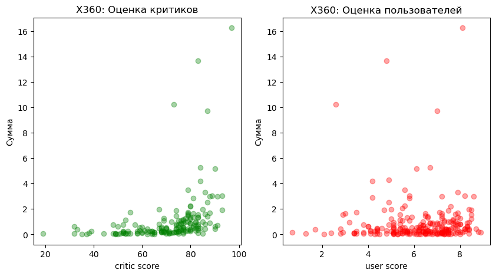

```python
# размечаем пространство для вывода графиков
fig, (ax1, ax2) = plt.subplots(
    nrows=1, ncols=2,
    figsize=(10, 5)
)

# построение и оформление графика рассеивания для отзывов критиков
ax1.scatter(x=data_critic_score_x360.critic_score,
            y=data_critic_score_x360.total_sale,
            alpha=0.35,
            color='green');
ax1.set_title('X360: Оценка критиков')
ax1.set_xlabel('critic score')
ax1.set_ylabel('Сумма')

# построение и оформление графика рассеивания для отзывов пользователей
ax2.scatter(x=data_user_score_x360.user_score,
            y=data_user_score_x360.total_sale,
            alpha=0.35,
            color='red');
ax2.set_title('X360: Оценка пользователей')
ax2.set_xlabel('user score')
ax2.set_ylabel('Сумма');
```

```python
# посчитаем коэффициенты корреляции
print('X360:')
print('Коэффициент корреляции глобальных продаж и оценки критиков:', round(data_critic_score_x360['total_sale'].corr(data_critic_score_x360['critic_score']), 3))
print('Коэффициент корреляции глобальных продаж и оценки пользователей:', round(data_user_score_x360['total_sale'].corr(data_user_score_x360['user_score']), 3))
```

```
X360:
Коэффициент корреляции глобальных продаж и оценки критиков: 0.361
Коэффициент корреляции глобальных продаж и оценки пользователей: 0.006
```

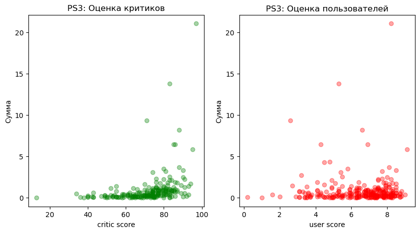

```python
# размечаем пространство для вывода графиков
fig, (ax1, ax2) = plt.subplots(
    nrows=1, ncols=2,
    figsize=(10, 5)
)

# построение и оформление графика рассеивания для отзывов критиков
ax1.scatter(x=data_critic_score_ps3.critic_score,
            y=data_critic_score_ps3.total_sale,
            alpha=0.35,
            color='green');
ax1.set_title('PS3: Оценка критиков')
ax1.set_xlabel('critic score')
ax1.set_ylabel('Сумма')

# построение и оформление графика рассеивания для отзывов пользователей
ax2.scatter(x=data_user_score_ps3.user_score,
            y=data_user_score_ps3.total_sale,
            alpha=0.35,
            color='red');
ax2.set_title('PS3: Оценка пользователей')
ax2.set_xlabel('user score')
ax2.set_ylabel('Сумма');
```

```python
# посчитаем коэффициенты корреляции
print('PS3:')
print('Коэффициент корреляции глобальных продаж и оценки критиков:', round(data_critic_score_ps3['total_sale'].corr(data_critic_score_ps3['critic_score']), 3))
print('Коэффициент корреляции глобальных продаж и оценки пользователей:', round(data_user_score_ps3['total_sale'].corr(data_user_score_ps3['user_score']), 3))
```

```
PS3:
Коэффициент корреляции глобальных продаж и оценки критиков: 0.331
Коэффициент корреляции глобальных продаж и оценки пользователей: -0.005
```

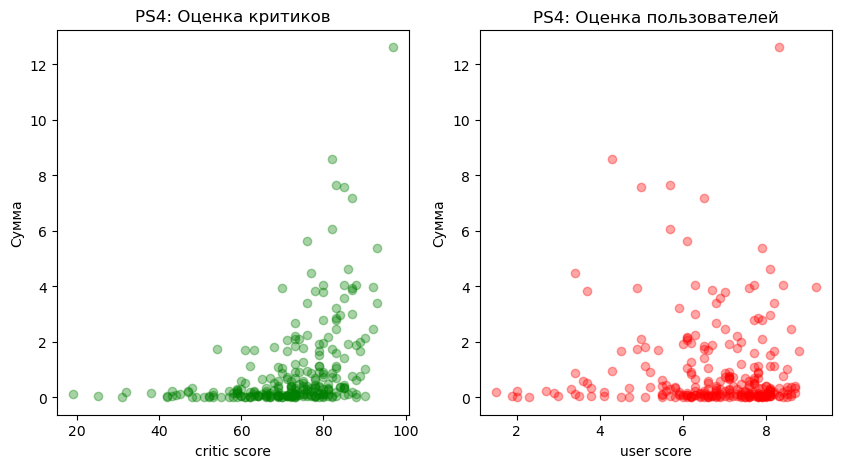

```python
# размечаем пространство для вывода графиков
fig, (ax1, ax2) = plt.subplots(
    nrows=1, ncols=2,
    figsize=(10, 5)
)

# построение и оформление графика рассеивания для отзывов критиков
ax1.scatter(x=data_critic_score_ps4.critic_score,
            y=data_critic_score_ps4.total_sale,
            alpha=0.35,
            color='green');
ax1.set_title('PS4: Оценка критиков')
ax1.set_xlabel('critic score')
ax1.set_ylabel('Сумма')

# построение и оформление графика рассеивания для отзывов пользователей
ax2.scatter(x=data_user_score_ps4.user_score,
            y=data_user_score_ps4.total_sale,
            alpha=0.35,
            color='red');
ax2.set_title('PS4: Оценка пользователей')
ax2.set_xlabel('user score')
ax2.set_ylabel('Сумма');
```

```python
# посчитаем коэффициенты корреляции
print('PS4:')
print('Коэффициент корреляции глобальных продаж и оценки критиков:', round(data_critic_score_ps4['total_sale'].corr(data_critic_score_ps4['critic_score']), 3))
print('Коэффициент корреляции глобальных продаж и оценки пользователей:', round(data_user_score_ps4['total_sale'].corr(data_user_score_ps4['user_score']), 3))
```

```
PS4:
Коэффициент корреляции глобальных продаж и оценки критиков: 0.407
Коэффициент корреляции глобальных продаж и оценки пользователей: -0.032
```

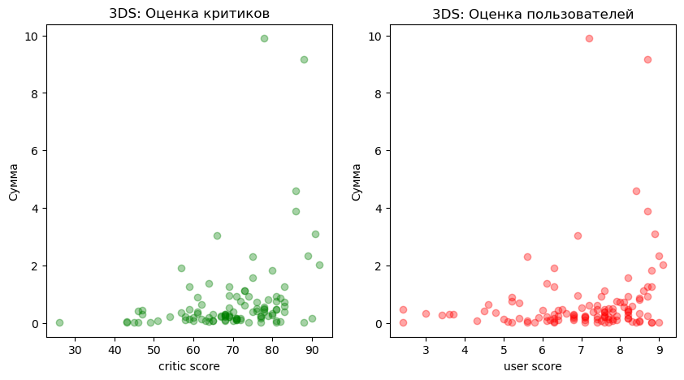

```python
# размечаем пространство для вывода графиков
fig, (ax1, ax2) = plt.subplots(
    nrows=1, ncols=2,
    figsize=(10, 5)
)

# построение и оформление графика рассеивания для отзывов критиков
ax1.scatter(x=data_critic_score_3ds.critic_score,
            y=data_critic_score_3ds.total_sale,
            alpha=0.35,
            color='green');
ax1.set_title('3DS: Оценка критиков')
ax1.set_xlabel('critic score')
ax1.set_ylabel('Сумма')

# построение и оформление графика рассеивания для отзывов пользователей
ax2.scatter(x=data_user_score_3ds.user_score,
            y=data_user_score_3ds.total_sale,
            alpha=0.35,
            color='red');
ax2.set_title('3DS: Оценка пользователей')
ax2.set_xlabel('user score')
ax2.set_ylabel('Сумма');
```

```python
# посчитаем коэффициенты корреляции
print('3DS:')
print('Коэффициент корреляции глобальных продаж и оценки критиков:', round(data_critic_score_3ds['total_sale'].corr(data_critic_score_3ds['critic_score']), 3))
print('Коэффициент корреляции глобальных продаж и оценки пользователей:', round(data_user_score_3ds['total_sale'].corr(data_user_score_3ds['user_score']), 3))
```

```
3DS:
Коэффициент корреляции глобальных продаж и оценки критиков: 0.321
Коэффициент корреляции глобальных продаж и оценки пользователей: 0.198
```

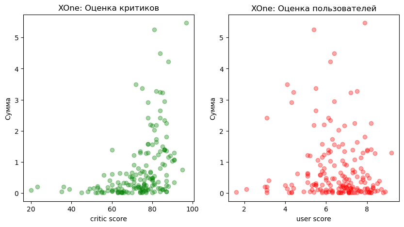

```python
# размечаем пространство для вывода графиков
fig, (ax1, ax2) = plt.subplots(
    nrows=1, ncols=2,
    figsize=(10, 5)
)

# построение и оформление графика рассеивания для отзывов критиков
ax1.scatter(x=data_critic_score_x0ne.critic_score,
            y=data_critic_score_x0ne.total_sale,
            alpha=0.35,
            color='green');
ax1.set_title('XOne: Оценка критиков')
ax1.set_xlabel('critic score')
ax1.set_ylabel('Сумма')

# построение и оформление графика рассеивания для отзывов пользователей
ax2.scatter(x=data_user_score_x0ne.user_score,
            y=data_user_score_x0ne.total_sale,
            alpha=0.35,
            color='red');
ax2.set_title('XOne: Оценка пользователей')
ax2.set_xlabel('user score')
ax2.set_ylabel('Сумма');
```

```python
# посчитаем коэффициенты корреляции
print('XOne:')
print('Коэффициент корреляции глобальных продаж и оценки критиков:', round(data_critic_score_x0ne['total_sale'].corr(data_critic_score_x0ne['critic_score']), 3))
print('Коэффициент корреляции глобальных продаж и оценки пользователей:', round(data_user_score_x0ne['total_sale'].corr(data_user_score_x0ne['user_score']), 3))
```

```
XOne:
Коэффициент корреляции глобальных продаж и оценки критиков: 0.417
Коэффициент корреляции глобальных продаж и оценки пользователей: -0.069
```

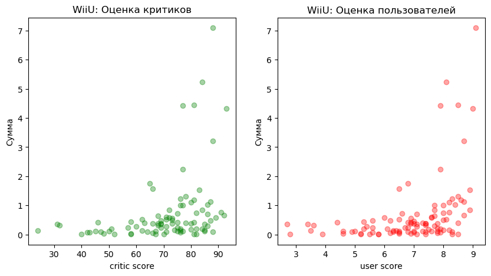

```python
# размечаем пространство для вывода графиков
fig, (ax1, ax2) = plt.subplots(
    nrows=1, ncols=2,
    figsize=(10, 5)
)

# построение и оформление графика рассеивания для отзывов критиков
ax1.scatter(x=data_critic_score_wiiu.critic_score,
            y=data_critic_score_wiiu.total_sale,
            alpha=0.35,
            color='green');
ax1.set_title('WiiU: Оценка критиков')
ax1.set_xlabel('critic score')
ax1.set_ylabel('Сумма')

# построение и оформление графика рассеивания для отзывов пользователей
ax2.scatter(x=data_user_score_wiiu.user_score,
            y=data_user_score_wiiu.total_sale,
            alpha=0.35,
            color='red');
ax2.set_title('WiiU: Оценка пользователей')
ax2.set_xlabel('user score')
ax2.set_ylabel('Сумма');
```

```python
# посчитаем коэффициенты корреляции
print('WiiU:')
print('Коэффициент корреляции глобальных продаж и оценки критиков:', round(data_critic_score_wiiu['total_sale'].corr(data_critic_score_wiiu['critic_score']), 3))
print('Коэффициент корреляции глобальных продаж и оценки пользователей:', round(data_user_score_wiiu['total_sale'].corr(data_user_score_wiiu['user_score']), 3))
```

```
WiiU:
Коэффициент корреляции глобальных продаж и оценки критиков: 0.348
Коэффициент корреляции глобальных продаж и оценки пользователей: 0.4
```

Корреляция между продажами и оценками критиков слабая. Зависимость между продажами и оценками критиков у платформ: XOne(0.417), PS4(0.407), X036(0.361), WiiU(0.348), PS3(0.331), 3DS(0.321) практически у всех одинаковая.

```python
# групировка по жанрам, сортировка и выборка данных
data_year_of_release_all2011 = data.query('year_of_release > 2011').reset_index(drop=True)
genre_total_sale = data_year_of_release_all2011.groupby(['genre'], as_index=False) \
                     .agg({'total_sale': 'median'})\
                     .sort_values('total_sale', ascending=False)
genre_total_sale.head(100)
```

|  | genre | total_sale |
| --- | --- | --- |
| 8 | Shooter | 0.440 |
| 10 | Sports | 0.240 |
| 4 | Platform | 0.210 |
| 7 | Role-Playing | 0.140 |
| 6 | Racing | 0.140 |
| 2 | Fighting | 0.130 |
| 0 | Action | 0.120 |
| 3 | Misc | 0.120 |
| 9 | Simulation | 0.120 |
| 11 | Strategy | 0.080 |
| 5 | Puzzle | 0.045 |
| 1 | Adventure | 0.030 |

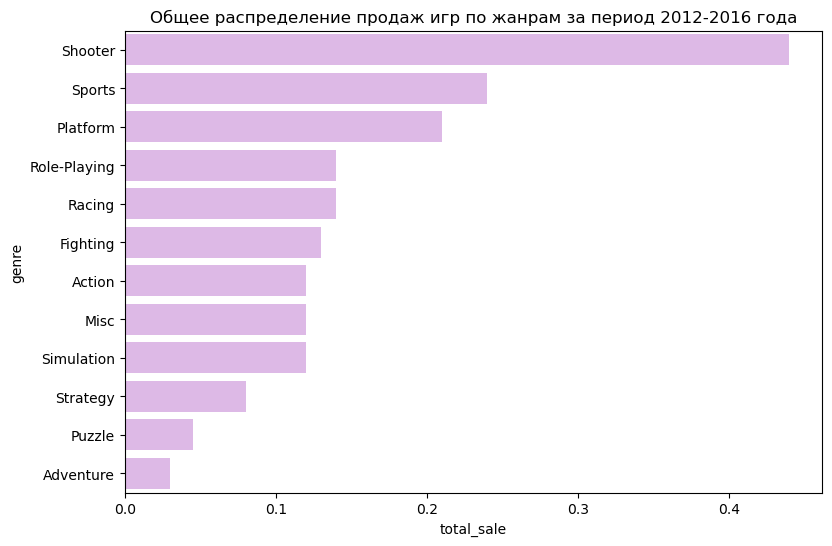

```python
# построим график по жанрам
plt.figure(figsize=(9, 6))

ax = sns.barplot(y=genre_total_sale.genre,
                 x=genre_total_sale.total_sale,
                 orient='h',
                 color='#e2b2ed',
                 ci=None);


plt.title('Общее распределение продаж игр по жанрам за период 2012-2016 года');
```

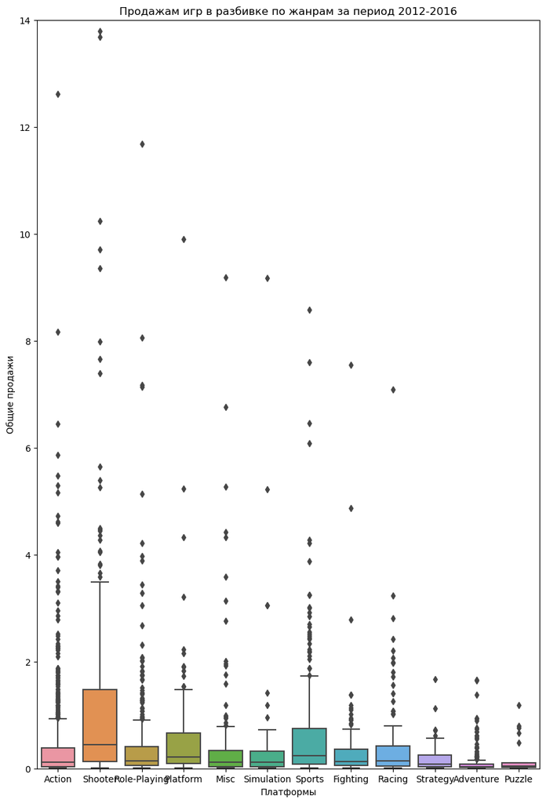

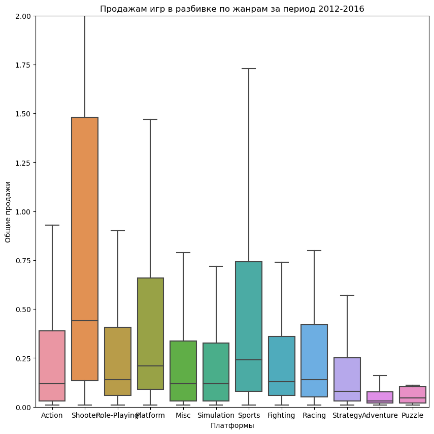

```python
# продажи за период 2012-2016 гг.
#popular_platforms_all = ['PS4', 'XOne', '3DS', 'DS', 'PC', 'PS3', 'PSP', 'PSV', 'Wii', 'WiiU']
#data_platforms_all2011 = data.query('platform in @popular_platforms_all & year_of_release > 2011').reset_index(drop=True)

plt.figure(figsize=(10,15))
ax=sns.boxplot (x = 'genre', y = 'total_sale', data = data_year_of_release_all2011)


plt.xlabel('Платформы');
plt.ylabel('Общие продажи');
plt.title('Продажам игр в разбивке по жанрам за период 2012-2016');
ax.set(ylim=(0, 14))

plt.figure(figsize=(10,10))
ax1=sns.boxplot (x = 'genre', y = 'total_sale', data = data_year_of_release_all2011, showfliers = False)
ax1.set(ylim=(0, 2))

plt.xlabel('Платформы');
plt.ylabel('Общие продажи');
plt.title('Продажам игр в разбивке по жанрам за период 2012-2016');
```

Самый популярный жанр при продаже игр - Shooter(0.440). Затем идут жанры - Sports(0.240), Platform(0.210). Самыми не популярными жанрами при продаже игр - Puzzle(0.045), Adventure(0.030).

Посмотрим популярность жанров с разбивкой по платформам.

```python
# групировка по жанрам и платформам, сортировка и выборка данных
genre_platform = data_year_of_release_all2011.groupby(['genre', 'platform'], as_index=False)\
                 .agg({'total_sale': 'median'})\
                 .sort_values('total_sale', ascending=False)
genre_platform
```

|  | genre | platform | total_sale |
| --- | --- | --- | --- |
| 70 | Role-Playing | DS | 4.540 |
| 48 | Platform | Wii | 1.125 |
| 87 | Shooter | XOne | 1.095 |
| 83 | Shooter | PS4 | 0.970 |
| 58 | Puzzle | Wii | 0.660 |
| 49 | Platform | WiiU | 0.580 |
| 84 | Shooter | PSV | 0.565 |
| 76 | Role-Playing | Wii | 0.530 |
| 103 | Sports | PS4 | 0.525 |
| 66 | Racing | WiiU | 0.510 |
| 78 | Role-Playing | X360 | 0.490 |
| 86 | Shooter | X360 | 0.470 |
| 108 | Sports | X360 | 0.465 |
| 118 | Strategy | X360 | 0.450 |
| 77 | Role-Playing | WiiU | 0.410 |
| 82 | Shooter | PS3 | 0.385 |
| 106 | Sports | Wii | 0.380 |
| 107 | Sports | WiiU | 0.365 |
| 102 | Sports | PS3 | 0.360 |
| 43 | Platform | DS | 0.345 |
| 109 | Sports | XOne | 0.335 |
| 9 | Action | X360 | 0.335 |
| 79 | Role-Playing | XOne | 0.320 |
| 46 | Platform | PS4 | 0.300 |
| 60 | Racing | 3DS | 0.280 |
| 40 | Misc | X360 | 0.270 |
| 3 | Action | PS3 | 0.260 |
| 116 | Strategy | Wii | 0.260 |
| 45 | Platform | PS3 | 0.250 |
| 32 | Misc | DS | 0.240 |

[output cut: 90 more lines]

[figure not shown]

```python
# построим график попопулярность жанров с разбивкой по платформам
plt.figure(figsize=(12, 8))

# задание параметров построения графика
ax = sns.barplot(x=genre_platform.genre,
                y=genre_platform.total_sale,

                 color='#6925c2',
                 palette=['#1f986c', '#ffff00', '#ff00ff'],
                 hue=genre_platform.platform,

                 );

# подписи осей и названия

plt.title('Распределение продаж игр по жанрам для PS4, XOne и 3DS начиная с 2012 года');
```

**Выводы:**

Данные за все периоды не нужны. Очень мало игр было выпущено за период с 1980 г. по 1994 г. Больше всего игр было выпущено в 2008-2009 года. Начиная с 2010 заметен спад продаж игр нового поколения консолей, который привёл к сокращению потенциального рынка сбыта. Топ-6 платформ являются главными претендентами для детального дальнейшего анализа по общим мировым продажам: PS2, X360, PS3, Wii, DS, PS.

Самые долгие платформы были PC - 31 год и Ninendo DS - 28 лет, Atari 2600 - 22 года. Меньше всего действовали платформы: Panasonic 3DO, SCD - 1 год, WonderSwan- 2 года. Некоторые вообще не пошли Game Gear, NEC PC-FX, NEC TurboGrafx. Средний возраст действия платформы 6-7 лет.

В нашу выборку с 2012 по 2016 год попали как платформы на пике популярности, так и новые зарождающиеся платформы, которые будут популярны в будущем.

Лидерами в продажи игр на 2017 г. остаются три платформы: PS4 и Xbox One. Остатки популярности имеются у Nintendo 3DS. Остальные платфоры в продажи игр к 2017 г. стремятся к нулю.

Анализируя графики и статистические данные по количеству продаж и максимальной ценой лидируют платформы PS3(21.05),PS4(14.63) и 3DS(14.60).

У платформы PS4 был не большой пик популярности платформы , а затем он резко спал. Платформы PS3 и 3DS были более стабильны по количеству продаж и максимальной ценой.

Для платформ PS3 наиболее продаваемой игрой стала 'Grand Theft Auto V' - 2013 года выпуска. Для платформ PS4 наиболее продаваемой игрой стала 'Call of Duty: Black Ops 3' - 2015 года выпуска. Для платформ 3DS наиболее продаваемой игрой стала 'Pokemon X/Pokemon Y' - 2013 года выпуска. Для платформ DS наиболее продаваемой игрой стала 'Pokemon Black 2/Pokemon White 2' - 2012 года выпуска. Для платформ XOne наиболее продаваемой игрой стала 'Call of Duty: Black Ops 3' - 2015 года выпуска. Для платформ WiiU наиболее продаваемой игрой стала 'Mario Kart 8' - 2014 года выпуска.

Самый популярный жанр при продаже игр - Shooter(0.440).Самыми не популярными жанрами при продаже игр - Puzzle(0.045), Adventure(0.030).

## Этап Составим портрет пользователя каждого региона

Определим для пользователя каждого региона наиболее популярные платформы, наиболее популярные жанры, а также влияние рейтинга ESRB на продажи по регионам.

Определим самые популярные платформы по регионам (NA, EU, JP)(топ-5).

Возьмем наиболее актуальные данные, сделав выборку за последние 5 лет (начиная с 2012 года).

```python
# отбираем данные за последние пять лет
data2011 = data[data['year_of_release'] > 2011].reset_index(drop=True)
```

```python
# получаем срез данных по регионам
data_region = data2011[['platform', 'na_sales', 'eu_sales', 'jp_sales']] \
    .groupby('platform', as_index=False) \
    .agg({'na_sales': 'sum', 'eu_sales': 'sum', 'jp_sales': 'sum'}) \
    .melt(id_vars=['platform']) \
    .sort_values('value', ascending=False)
data_region.head()
```

|  | platform | variable | value |
| --- | --- | --- | --- |
| 15 | PS4 | eu_sales | 141.09 |
| 9 | X360 | na_sales | 140.05 |
| 4 | PS4 | na_sales | 108.74 |
| 14 | PS3 | eu_sales | 106.86 |
| 3 | PS3 | na_sales | 103.38 |

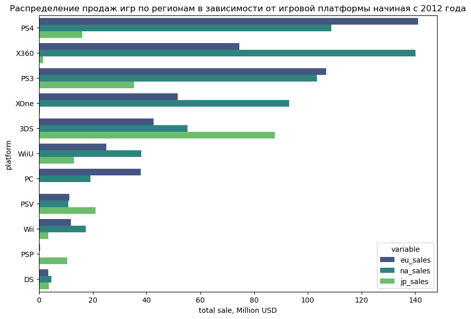

```python
# размер фигуры
plt.figure(figsize=(10, 7))

ax = sns.barplot(y=data_region.platform,
                 x=data_region.value,
                 orient='h',
                 color='#6925c2',
                 palette='viridis',
                 hue=data_region.variable);

plt.xlabel('total sale, Million USD')
plt.title('Распределение продаж игр по регионам в зависимости от игровой платформы начиная с 2012 года');
```

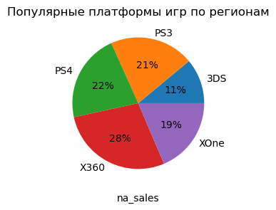

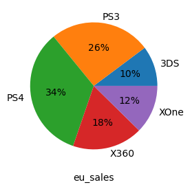

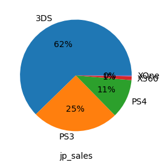

```python
# строим круговые диаграммы
data_platform5 = ["PS4", "X360", "PS3", "XOne", "3DS"]
data_platform_all = data2011.query('platform in @data_platform5')
ax=data_bar_na = data_platform_all.pivot_table(index='platform',  values='na_sales', aggfunc=('sum')).plot(kind='pie', y='na_sales', autopct='%1.0f%%', figsize=(5, 3))
ax1=data_bar_na = data_platform_all.pivot_table(index='platform',  values='eu_sales', aggfunc=('sum')).plot(kind='pie', y='eu_sales', autopct='%1.0f%%', figsize=(5, 3))
ax2=data_bar_na = data_platform_all.pivot_table(index='platform',  values='jp_sales', aggfunc=('sum')).plot(kind='pie', y='jp_sales', autopct='%1.0f%%', figsize=(5, 3))

ax.set(title='Популярные платформы игр по регионам',
xlabel = 'na_sales', ylabel='')
ax1.set(xlabel = 'eu_sales', ylabel='')
ax2.set(xlabel = 'jp_sales', ylabel='')
ax.legend().set_visible(False)
ax1.legend().set_visible(False)
ax2.legend().set_visible(False)
plt.show()
```

Топ-5 самых популярных платформ: PS4, Xbox 360, PS3, Xbox 0ne, Nintendo 3DS.

В Европе наиболее популярны платформы производителя Sony:PS4, PS3. В Северной Америке наиболее популярны игровые платформы производителей: Microsoft(Xbox 360, Xbox 0ne), Sony(PS4, PS3). В Японии наиболее популярны игровые платформы местного производителя Nintendo: Nintendo 3DS.